# Data Load

```python
import pandas as pd
df_viewer_data = pd.read_csv("https://storage.googleapis.com/datalynn-datasets/interview-challenge/technology/Amazon_Studios/ViewerData.csv")
df_show_data = pd.read_csv("https://storage.googleapis.com/datalynn-datasets/interview-challenge/technology/Amazon_Studios/ShowData.csv")
```

## Question 1

**Scenario**: You have been provided with the `ViewerData` and `ShowData` tables. The data has been sourced from various departments, and before diving into deeper analysis, it's essential to ensure that the data is clean and consistent.

**Task**: Identify and rectify any outliers in the `Rating` column. Also, check for any missing values in both tables and impute them using a suitable strategy. Ensure that the `ReleaseDate` in `ShowData` table follows a unified format of "YYYY-MM-DD".

## Solution:

### Hints:

1. Use describe() method to get an understanding of the statistical distribution of the Rating column.
2. Visual tools like boxplots can help in identifying outliers.
3. Iteratively use the pd.to_datetime() function with the provided formats to make the date format consistent.

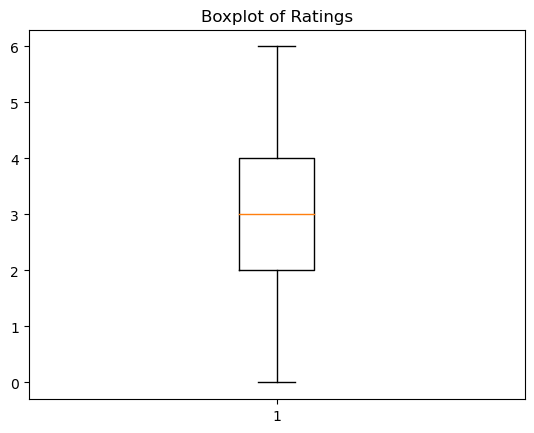

```
Unnamed: 0       0
ViewerID         0
AgeGroup         0
Region           0
Rating           0
WatchDuration    0
ShowID           0
dtype: int64
Unnamed: 0         0
ShowID             0
Genre              0
ReleaseDate        0
MarketingSpend    10
dtype: int64
    Unnamed: 0 ShowID        Genre ReleaseDate  MarketingSpend
0            0  S0000        Drama  2023-09-19      1418601.80
8            8  S0008     Thriller  2023-11-09      1418601.80
10          10  S0010        Drama  2023-09-09      8622119.42
11          11  S0011  Documentary  2023-09-08       399653.03
12          12  S0012       Comedy  2023-07-09       584726.47
```

```python
import pandas as pd
import numpy as np
import matplotlib.pyplot as plt
import warnings
warnings.filterwarnings("ignore")

# Load the data into pandas DataFrames (this step would vary based on the data source)
viewer_data = df_viewer_data  # Insert loading method here
show_data = df_show_data    # Insert loading method here

# Identify outliers in the Rating column
plt.boxplot(viewer_data['Rating'])
plt.title('Boxplot of Ratings')
plt.show()

# Let's consider ratings outside of 1-5 as outliers and filter them
viewer_data = viewer_data[(viewer_data['Rating'] >= 1) & (viewer_data['Rating'] <= 5)]

# Check for missing values in both tables
print(viewer_data.isnull().sum())
print(show_data.isnull().sum())

# Impute missing values (for this example, I'll fill numerical values with median and categorical with mode)
for column in viewer_data.columns:
    if viewer_data[column].dtype == 'O':  # Check if column is categorical
        viewer_data[column].fillna(viewer_data[column].mode()[0], inplace=True)
    else:
        viewer_data[column].fillna(viewer_data[column].median(), inplace=True)

for column in show_data.columns:
    if show_data[column].dtype == 'O':
        show_data[column].fillna(show_data[column].mode()[0], inplace=True)
    else:
        show_data[column].fillna(show_data[column].median(), inplace=True)

# Ensure ReleaseDate is in the "YYYY-MM-DD" format
formats = ["%d-%m-%Y", "%Y/%m/%d", "%m-%d-%Y"]
for format in formats:
    show_data['ReleaseDate'] = pd.to_datetime(show_data['ReleaseDate'], format=format, errors='coerce')

# Drop rows where ReleaseDate is still NaT (i.e., not a valid date after conversion attempts)
show_data.dropna(subset=['ReleaseDate'], inplace=True)
print(show_data.head())
```

### Summary:

The solution starts by visualizing the Rating column to identify potential outliers. Ratings outside of the 1-5 range are filtered out. Next, the code checks and imputes any missing values in both tables. The ReleaseDate column in ShowData is then formatted to "YYYY-MM-DD" by iterating over the given date formats using pd.to_datetime(). Any rows where the date is still not valid (represented as NaT) after the format attempts are dropped.

## Question 2

**Scenario**: Amazon Studios wants to understand the relationship between marketing expenditure and viewer ratings for each show.

**Task**: Using a Common Table Expression (CTE), create an intermediary table that joins the `ViewerData` and `ShowData` on `ShowID`. From this, derive the average rating for each show, and its associated marketing spend. Next, using an analytic function, rank shows based on average ratings. Lastly, identify any shows that have identical average ratings (duplicates).

## Solution:

### Hints:

1. Connect to an in-memory SQLite database using sqlite3.
2. Use the to_sql() function from pandas to push the DataFrame to this database.
3. Use a CTE to join the ViewerData and ShowData tables on ShowID and calculate the required results.

```python
import sqlite3

# Connect to an in-memory SQLite database
conn = sqlite3.connect(':memory:')

# Convert pandas DataFrames to SQL tables
viewer_data.to_sql('ViewerData', conn, index=False, if_exists='replace')
show_data.to_sql('ShowData', conn, index=False, if_exists='replace')

# SQL query
query = """
WITH ShowRating AS (
    SELECT
        s.ShowID,
        s.Genre,
        s.ReleaseDate,
        s.MarketingSpend,
        AVG(v.Rating) as AvgRating
    FROM
        ShowData s
    JOIN
        ViewerData v ON s.ShowID = v.ShowID
    GROUP BY
        s.ShowID, s.Genre, s.ReleaseDate, s.MarketingSpend
)

SELECT
    ShowID,
    Genre,
    ReleaseDate,
    MarketingSpend,
    AvgRating,
    RANK() OVER(ORDER BY AvgRating DESC) as Rank
FROM
    ShowRating
WHERE
    ShowRating.AvgRating IN (SELECT AvgRating FROM ShowRating GROUP BY AvgRating HAVING COUNT(ShowID) > 1)
"""

result_df = pd.read_sql(query, conn)

print(result_df)

# Close the connection
conn.close()
```

```
   ShowID        Genre          ReleaseDate  MarketingSpend  AvgRating  Rank
0   S0028     Thriller  2023-08-22 00:00:00      2128844.78   3.500000     1
1   S0099  Documentary  2023-12-06 00:00:00       283054.44   3.500000     1
2   S0041        Drama  2023-08-09 00:00:00      6888837.95   3.250000     3
3   S0061        Drama  2023-07-20 00:00:00      1662423.93   3.250000     3
4   S0047       Comedy  2023-08-03 00:00:00      1731063.28   3.200000     5
5   S0098  Documentary  2023-06-13 00:00:00       160350.20   3.200000     5
6   S0062        Drama  2023-07-19 00:00:00      1842169.94   3.100000     7
7   S0076  Documentary  2023-07-05 00:00:00       182280.50   3.100000     7
8   S0017        Drama  2023-02-09 00:00:00      7732722.15   3.000000     9
9   S0067  Documentary  2023-07-14 00:00:00       228134.58   3.000000     9
10  S0083       Action  2023-06-28 00:00:00      1319918.68   3.000000     9
11  S0008     Thriller  2023-11-09 00:00:00      1418601.80   2.875000    12
12  S0015       Comedy  2023-09-04 00:00:00      1954088.97   2.875000    12
13  S0059     Thriller  2023-07-22 00:00:00      1231154.35   2.777778    14
14  S0077  Documentary  2023-04-07 00:00:00       318935.02   2.777778    14
15  S0026       Comedy  2023-08-24 00:00:00      1702402.38   2.750000    16
16  S0082       Action  2023-06-29 00:00:00      1571898.40   2.750000    16
17  S0012       Comedy  2023-07-09 00:00:00       584726.47   2.666667    18
18  S0043       Action  2023-08-07 00:00:00      1241831.90   2.666667    18
19  S0050        Drama  2023-07-31 00:00:00      1507599.71   2.666667    18
20  S0023  Documentary  2023-08-27 00:00:00       338470.15   2.500000    21
21  S0040  Documentary  2023-10-08 00:00:00       410688.57   2.500000    21
22  S0011  Documentary  2023-09-08 00:00:00       399653.03   2.428571    23
23  S0036       Action  2023-08-14 00:00:00      1972887.28   2.428571    23
24  S0084     Thriller  2023-06-27 00:00:00      1495014.17   2.428571    23
25  S0049  Documentary  2023-08-01 00:00:00       151323.04   2.333333    26
26  S0080     Thriller  2023-01-07 00:00:00      1857577.59   2.333333    26
```

### Summary:

The solution begins by connecting to an in-memory SQLite database. Both DataFrames are then loaded into this database. An SQL query with a CTE is executed which calculates the average rating for each show and its associated marketing spend. This CTE is then used in the main query to rank shows based on average ratings and to identify shows with duplicate average ratings. The result is printed to the console.

## Question 3

**Scenario**: Amazon Studios is curious if there's a statistically significant relationship between `MarketingSpend` and the average `Rating` a show receives.

**Task**: Firstly, formulate a hypothesis to test this relationship. Calculate the correlation coefficient between `MarketingSpend` and `Rating`. Based on the coefficient, conclude if the relationship is significant or not. Implement the calculation using appropriate statistical tools or code.

## Solution:

### Hints:

1. The correlation coefficient value ranges from -1 to 1. A value closer to 1 implies a strong positive correlation.
2. Use pearsonr from scipy.stats to calculate the correlation coefficient and p-value.
3. Consider a standard significance level (like 0.05) to determine if the correlation is statistically significant.

```python
from scipy.stats import pearsonr

# Assuming the data after joining is in a DataFrame called 'merged_data'
merged_data = viewer_data.merge(show_data, on='ShowID')
correlation_coefficient, p_value = pearsonr(merged_data['MarketingSpend'], merged_data['Rating'])

print(f"Correlation Coefficient: {correlation_coefficient}")
print(f"P-value: {p_value}")

if p_value < 0.05:
    print("The relationship is statistically significant.")
else:
    print("The relationship is not statistically significant.")
```

```
Correlation Coefficient: 0.019530234965151484
P-value: 0.6682179433424521
The relationship is not statistically significant.
```

### Summary:

The solution calculates the correlation coefficient between MarketingSpend and Rating using the pearsonr function. The p-value obtained indicates the statistical significance of the correlation. If the p-value is less than 0.05, the correlation is considered significant.

## Question 4

**Scenario**: A recently released show has garnered significant attention, but its ratings are not as expected. The show had a high marketing budget, but the return, in terms of audience ratings and engagement, is lower than the predicted metrics.

**Task**: How would you approach this situation from a business perspective? What factors, apart from ratings, would you consider, and what recommendations would you provide to the content and marketing teams based on the data from `ViewerData` and `ShowData`?

## Solution:

### Hints:

1. Consider the demographic data (like AgeGroup and Region) to understand if the show appealed more to a specific audience.
2. The WatchDuration column can indicate audience engagement.
3. Analyze if there's a genre trend with high MarketingSpend but low ratings.

```python
# Analyze the distribution of ratings across different age groups and regions
age_group_ratings = merged_data.groupby('AgeGroup')['Rating'].mean()
region_ratings = merged_data.groupby('Region')['Rating'].mean()

# Analyze average watch duration
average_watch_duration = merged_data['WatchDuration'].mean()

# Investigate if there's a trend with genre
genre_trend = merged_data.groupby('Genre')['Rating'].mean().sort_values()
```

```python
# Suppose the show's ID is "S0004". Filter the data for this particular show.
specific_show_data = viewer_data[viewer_data['ShowID'] == 'S0004']

# Analyze viewers' demographics
age_group_distribution = specific_show_data['AgeGroup'].value_counts(normalize=True) * 100
region_distribution = specific_show_data['Region'].value_counts(normalize=True) * 100

# Calculate average watch duration
average_watch_duration = specific_show_data['WatchDuration'].mean()

print("Age Group Distribution:", age_group_distribution)
print("Region Distribution:", region_distribution)
print("Average Watch Duration:", average_watch_duration)
```

```
Age Group Distribution: AgeGroup
18-24    37.5
55-64    25.0
65+      25.0
35-44    12.5
Name: proportion, dtype: float64
Region Distribution: Region
East     50.0
West     37.5
North    12.5
Name: proportion, dtype: float64
Average Watch Duration: 102.875
```

### Recommendations:

1. Audience Analysis: Understanding your core audience is vital. If the show was marketed to a broad audience but only a specific age group or region appreciated it, then the content might not resonate with everyone. The marketing and content teams can work together to either adjust the content to appeal to the broader audience or hone marketing strategies to target the specific group that shows higher engagement.
2. Viewer Engagement: If the average watch duration is significantly less than the show's full duration, viewers might be dropping off early. This indicates a need to re-evaluate the show's initial episodes or segments. The content team should focus on making the beginning more engaging or reduce potential barriers like pacing issues or lack of compelling story hooks.
3. Feedback Mechanism: Consider introducing a feedback mechanism where viewers can provide specific reasons for their ratings. This qualitative data can offer deeper insights into what's working and what's not.
4. External Factors: External factors, such as competitive shows releasing at the same time or major events clashing with show timings, can affect viewership and ratings. It's essential to be aware of the broader industry trends and events.
5. Marketing Analysis: A high marketing budget does not always equate to success. It's crucial to evaluate the marketing channels and campaigns used to promote the show. Were they reaching the intended audience? Was the messaging aligned with the show's content?
6. Content Analysis: Sometimes, the problem might be with the content itself. Consider holding focus group sessions or surveys to dive deeper into content-specific issues.

### Summary:

The business situation indicates a gap between marketing spend and ROI in terms of viewer ratings and engagement. By diving deep into viewer demographics, engagement metrics, and qualitative feedback, one can glean actionable insights. Addressing the core issues—be it in content, marketing strategies, or external factors—will help in better aligning future projects with audience expectations.